# 第15回 ggplot2とデータの可視化

プログラミング演習Ⅰ

佐藤 秀保

sato0035@toyo.jp

## 準備

授業中のコードはすべてスクリプトに書き実行すること

## データの説明

- 600行5列の仮想アンケートデータ

| 変数名 | 意味 | 型 | とる値 | 備考 |
| --- | --- | --- | --- | --- |
| ID | 回答者番号 | num | 1~600の整数 |  |
| gender | 性別 | chr | m, f | **m**ale, **f**emale |
| age_group | 年代 | chr | in_20, …, in_70 | 20代,…,70代以上 |
| income | 年収 | num |  | 万円 |
| calories | 摂取ｶﾛﾘｰ | num |  | kcal |

## ggplot2 じーじーぷろっとつー

- グラフ作成の基本パッケージ
  - ヒストグラム：geom_histogram関数
  - 棒グラフ ：geom_bar関数
  - 折れ線グラフ：geom_line関数
  - 散布図 ：geom_point関数
  - 箱ひげ図 ：geom_boxplot関数 など
- geomはgeometric object（幾何学的オブジェクト）の意味

### お絵描きのイメージ

- レイヤーを追加していく

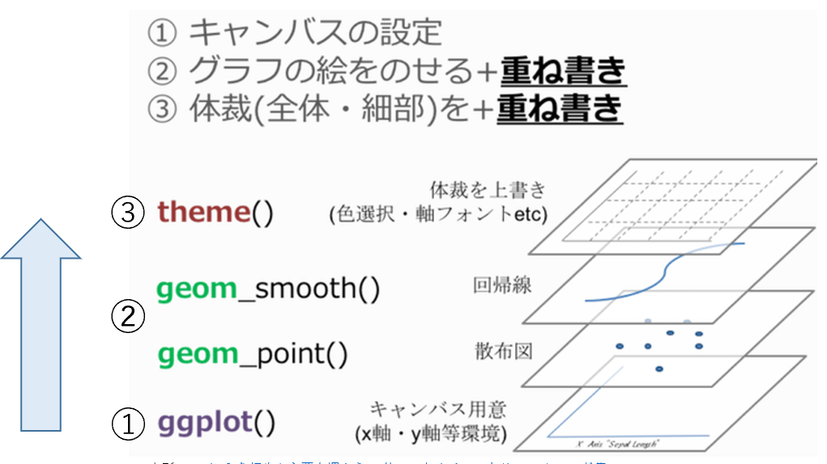

### 文法

- **ggplot(データフレーム, aes(x軸やy軸の設定など)) +**

  **geom_〇〇(必要な設定) +**

  **他のレイヤー +**

  **theme(必要なら文字の大きさなど)**
  1. ggplot内のaes関数（**aes**thetic；美的）で軸の指定等
  2. geom_〇〇関数を使用し適宜，適切な引数をとる
  3. 必要に応じ他のレイヤーの追加やthemeの設定
- レイヤーは+でつなぐ
- ggplot関数の第１引数はデータフレームなのでパイプを使うこと多し

## ヒストグラム

- 特定の変数について，分布を描く
- 縦軸は度数と決まっているので，横軸をggplot関数のaesで指定

```r
#ヒストグラム（カロリー）
#g1に保存
g1 <- questionnaire %>%
  ggplot(aes(x = calories)) +
  geom_histogram()
#グラフを呼び出し
g1
```

### ビンの幅

- ビンbin：ヒストグラムの１つの棒
- geom_histogram関数のキーワード引数「binwidth =」で幅を指定

```r
#ビンbinの幅widthをデフォルトから広げる
g2 <- questionnaire %>%
  ggplot(aes(x = calories)) +
  geom_histogram(binwidth = 300)
g2
```

```r
#ビンbinの幅widthをデフォルトから狭める
g3 <- questionnaire %>%
  ggplot(aes(x = calories)) +
  geom_histogram(binwidth = 20)
g3
```

### 詳細なビン幅

- 各ビンの幅をマニュアルに設定可能
  - geom_histogram関数のキーワード引数「breaks = 各ビンの開始位置のアトミックベクトル」で指定
  - 500kcal～3300kcalまで100kcalの幅で指定したいときは

    geom_histogram(breaks = c(500, 600, 700, 800, …, 3300)
  - 入力が大変なので，同一の幅を刻むアトミックベクトルを生成する関数

    seq(始値，終値，幅)

    を使うのが便利

```r
#ビンの幅のマニュアル指定
g4 <- questionnaire %>%
  ggplot(aes(x = calories)) +
  geom_histogram(breaks= seq(500, 3300, 100)) #500から3300まで100刻みのアトミックベクトルを生成し指定
g4
```

### 色の塗りつぶし，枠線の色

- geom_histogram関数のキーワード引数
  - 「fill =」でビンの塗りつぶし色を，
  - 「color =」で枠線の色を，指定

```r
#塗りつぶしと枠線の色
g5 <- questionnaire %>%
  ggplot(aes(x = calories)) +
  geom_histogram(breaks= seq(500, 3300, 100), fill = "skyblue", color = "black")
g5
```

### 色の名称

- 下図のリンク先を参照

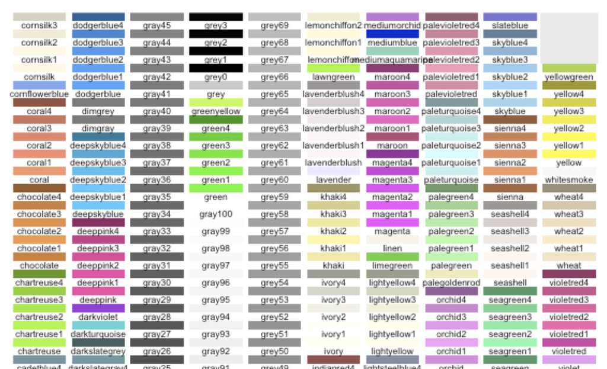

### タイトル・軸ラベル

- labs関数のレイヤー追加でタイトルや軸ラベルを追加・変更可

```r
#ラベルのレイヤー追加
g6 <- questionnaire %>%
  ggplot(aes(x = calories)) +
  geom_histogram(breaks= seq(500, 3300, 100), fill = "skyblue", color = "black") +
  labs(title = "Histogram of Average Calories",
       x = "Calories (kcal)",
       y = "Frequency")
g6
```

### 保存したグラフへのレイヤー追加

- 一度，「g6」など名前を付けて保存したグラフにレイヤーを追加したい場合はそのままそれに「+」でレイヤーを追加可

```r
#既存のグラフにレイヤー追加
#labsのレイヤーの無いg5にlabsを追加し保存
g7 <- g5 +
  labs(title = "Histogram of Average Calories",
       x = "Calories (kcal)",
       y = "Frequency")
g7
```

### 軸目盛

- マニュアルで軸目盛を指定可
  - 横軸はscale_x_continuous関数，縦軸はscale_y_continuous関数のキーワード引数「breaks = 各軸目盛の値のアトミックベクトル」で指定

```r
#軸目盛
#横軸は0～3300の100刻み，縦軸は0~70の10刻み
g8 <- g7 +
  scale_x_continuous(breaks = seq(0, 3300, by = 100)) +
  scale_y_continuous(breaks = seq(0, 70, by = 10))
g8
```

### フォント

- theme関数のレイヤー追加でフォントを変更可

```r
#長いのでここはいちいち佐藤も覚えていない
g9 <- g8 +
  theme(
    axis.text.x = element_text(size = 14),  # 横軸の目盛サイズ
    axis.text.y = element_text(size = 14),  # 縦軸の目盛サイズ
    axis.title.x = element_text(size = 16), # x軸ラベル
    axis.title.y = element_text(size = 16), # y軸ラベル
    plot.title = element_text(size = 18, face = "bold")  # タイトル
  )
g9
```

## 箱ひげ図

- 特定の変数について，分布の要約を描く
- 少なくとも縦軸をggplot関数のaesで指定
  - 箱の中は全体の50%を占める
  - 箱は上から75%点，50%点，25%点
  - ひげは通常，箱の大きさの±1.5倍までに存在する最大or最小値まで伸ばす
  - それ以外は外れ値として点で表す

```r
#箱ひげ図（カロリー）
g10 <- questionnaire %>%
  ggplot(aes(y = calories)) +
  geom_boxplot()
g10
```

```r
#塗りつぶしと枠線の色
g11 <- questionnaire %>%
  ggplot(aes(y = calories)) +
  geom_boxplot(fill = "lightgreen", color = "black")
g11
```

### 横軸の値の追加

- ggplot関数のaesで横軸も指定すれば，横軸別に箱ひげ図を描ける
  - ただし，横軸はカテゴリカルデータに限る

    ※第7回スライド4参照

```r
#横軸の追加（男女別のカロリーの箱ひげ図）
g12 <- questionnaire %>%
  ggplot(aes(x = gender, y = calories)) +
  geom_boxplot()
g12
```

### グループ別の塗りつぶし

- ggplot関数のaesでキーワード引数「fill = 色分けしたい変数」を指定することで，キャンバス全体でグループ別に色の塗りつぶしを適用可

```r
#グループ別の塗りつぶし（男女別の色分け）
g13 <- questionnaire %>%
  ggplot(aes(x = gender, y = calories, fill = gender)) +
  geom_boxplot()
g13
```

### グループ別の塗りつぶし（マニュアル）

- グループ別の塗りつぶしの色を，

  scale_fill_manual(values = c(“グループの値” = “色”, “グループの値” = “色”, ….)

  をレイヤー追加することでマニュアルで指定可

```r
g14 <- questionnaire %>%
  ggplot(aes(x = gender, y = calories, fill = gender)) +
  geom_boxplot() +
  scale_fill_manual(values = c("m" = "skyblue", "f" = "pink")) #fillで指定した値がmのときスカイブルー，fのときピンク
g14
```

## 演習

摂取カロリーの年代別の箱ひげ図を作成せよ．

ただし，年代別に色分けすること（マニュアルで指定する必要はない）．

## 課題

- ACEの小テスト：なし
- ACEのレポート：「第15回」
  - ローカルに保存したlecture15.Rを提出
  - **期限，明日の14:30まで！（模範解答を明日にはアップロード予定）**
- 課題用追加資料[「回帰分析」の動画](https://youtu.be/rrtRC-HOnLU)
  - 何か提出を求めるものではないが，試験範囲に含まれる